# Deep Learning Lab Session

```python
my_mnist_net.save('Models/network_200')
```

```
Iteration:  1/50[==============] -Error: 0.2601123664  -Training_Accuracy:  90.71  -time: 55.30
Iteration:  2/50[==============] -Error: 0.0842081193  -Training_Accuracy:  91.65  -time: 117.35
Iteration:  3/50[==============] -Error: 0.0681212441  -Training_Accuracy:  94.28  -time: 179.19
Iteration:  4/50[==============] -Error: 0.0598418982  -Training_Accuracy:  94.35  -time: 240.30
Iteration:  5/50[==============] -Error: 0.0585753484  -Training_Accuracy:  95.32  -time: 306.62
Iteration:  6/50[==============] -Error: 0.0534026373  -Training_Accuracy:  95.61  -time: 373.89
Iteration:  7/50[==============] -Error: 0.0509709999  -Training_Accuracy:  95.48  -time: 427.81
Iteration:  8/50[==============] -Error: 0.0495837576  -Training_Accuracy:  95.66  -time: 486.46
Iteration:  9/50[==============] -Error: 0.0462881112  -Training_Accuracy:  95.74  -time: 549.53
Iteration: 10/50[==============] -Error: 0.0478298053  -Training_Accuracy:  95.34  -time: 608.36
Iteration: 11/50[==============] -Error: 0.0447981064  -Training_Accuracy:  95.84  -time: 665.09
Iteration: 12/50[==============] -Error: 0.0434509234  -Training_Accuracy:  96.15  -time: 738.22
Iteration: 13/50[==============] -Error: 0.0424789623  -Training_Accuracy:  95.98  -time: 795.44
Iteration: 14/50[==============] -Error: 0.0405544601  -Training_Accuracy:  96.59  -time: 860.03
Iteration: 15/50[==============] -Error: 0.0404707281  -Training_Accuracy:  96.47  -time: 919.24
Iteration: 16/50[==============] -Error: 0.0389483332  -Training_Accuracy:  96.55  -time: 975.99
Iteration: 17/50[==============] -Error: 0.0388779885  -Training_Accuracy:  96.52  -time: 1032.78
Iteration: 18/50[==============] -Error: 0.0398964525  -Training_Accuracy:  96.61  -time: 1093.07
Iteration: 19/50[==============] -Error: 0.0372545528  -Training_Accuracy:  96.70  -time: 1150.48
Iteration: 20/50[==============] -Error: 0.0379363534  -Training_Accuracy:  96.74  -time: 1208.43
Iteration: 21/50[==============] -Error: 0.0367202732  -Training_Accuracy:  96.90  -time: 1274.46
Iteration: 22/50[==============] -Error: 0.0358902365  -Training_Accuracy:  96.72  -time: 1329.24
Iteration: 23/50[==============] -Error: 0.0367754400  -Training_Accuracy:  96.96  -time: 1384.01
Iteration: 24/50[==============] -Error: 0.0362455139  -Training_Accuracy:  96.97  -time: 1439.40
Iteration: 25/50[==============] -Error: 0.0357676384  -Training_Accuracy:  97.13  -time: 1520.30
Iteration: 26/50[==============] -Error: 0.0339429792  -Training_Accuracy:  96.92  -time: 1599.87
Iteration: 27/50[==============] -Error: 0.0350209648  -Training_Accuracy:  96.91  -time: 1666.39
Iteration: 28/50[==============] -Error: 0.0344826185  -Training_Accuracy:  97.16  -time: 1726.53
Iteration: 29/50[==============] -Error: 0.0349793539  -Training_Accuracy:  97.18  -time: 1783.05
Iteration: 30/50[==============] -Error: 0.0340100586  -Training_Accuracy:  97.08  -time: 1838.17
Iteration: 31/50[==============] -Error: 0.0345010635  -Training_Accuracy:  97.00  -time: 1893.38
Iteration: 32/50[==============] -Error: 0.0349939079  -Training_Accuracy:  97.13  -time: 1948.70
Iteration: 33/50[==============] -Error: 0.0323082160  -Training_Accuracy:  97.48  -time: 2004.25
Iteration: 34/50[==============] -Error: 0.0312857772  -Training_Accuracy:  97.07  -time: 2066.76
Iteration: 35/50[==============] -Error: 0.0328907223  -Training_Accuracy:  97.07  -time: 2132.96
Iteration: 36/50[==============] -Error: 0.0301062666  -Training_Accuracy:  97.26  -time: 2194.85
Iteration: 37/50[==============] -Error: 0.0314435743  -Training_Accuracy:  97.55  -time: 2256.96
Iteration: 38/50[==============] -Error: 0.0312924877  -Training_Accuracy:  97.40  -time: 2321.48
Iteration: 39/50[==============] -Error: 0.0302368669  -Training_Accuracy:  97.39  -time: 2394.38
Iteration: 40/50[==============] -Error: 0.0302038937  -Training_Accuracy:  97.46  -time: 2459.82
Iteration: 41/50[==============] -Error: 0.0302826628  -Training_Accuracy:  97.37  -time: 2526.30
Iteration: 42/50[==============] -Error: 0.0291101824  -Training_Accuracy:  97.63  -time: 2589.64
Iteration: 43/50[==============] -Error: 0.0290105464  -Training_Accuracy:  97.54  -time: 2657.33
Iteration: 44/50[==============] -Error: 0.0296435826  -Training_Accuracy:  97.39  -time: 2725.08
Iteration: 45/50[==============] -Error: 0.0303758824  -Training_Accuracy:  97.56  -time: 2788.01
Iteration: 46/50[==============] -Error: 0.0304985599  -Training_Accuracy:  97.62  -time: 2860.45
Iteration: 47/50[==============] -Error: 0.0306612862  -Training_Accuracy:  97.36  -time: 2918.88
Iteration: 48/50[==============] -Error: 0.0320300266  -Training_Accuracy:  97.38  -time: 2978.10
Iteration: 49/50[==============] -Error: 0.0310941607  -Training_Accuracy:  97.40  -time: 3050.60
Iteration: 50/50[==============] -Error: 0.0307798155  -Training_Accuracy:  97.47  -time: 3115.69
```

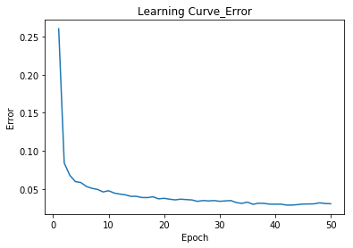

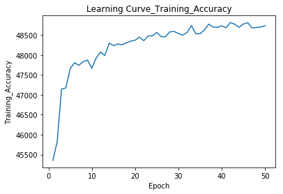

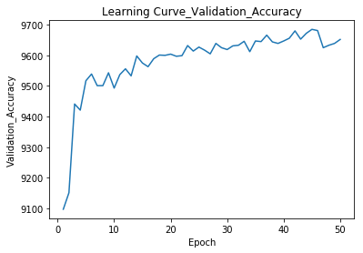

```python
from NeuralNetwork import *

my_mnist_net = NeuralNetwork(784,300,10,iterations=50, learning_rate = 1)


my_mnist_net.train_with_accuracy(training_data,validation_data)
```

```python
my_mnist_net.save('Models/network_300')
```

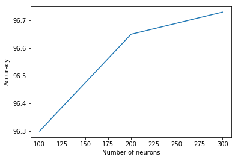

```python
X = [100,200,300]
Y = [96.3,96.65,96.73]
plt.xlabel('Number of neurons')
plt.ylabel('Accuracy')
plt.plot(X,Y)
plt.show()
```

We can observe that the accuracy on test data is pratically the same when the number of neurons in hidden layer is equal to 100,200 or 300. Moreover, the accuracies are very good : more than 96 % and the models don't overfit. Moreover, it takes more time to train our model when the number of neurons is high.

**Question 2.2.5 :** Add one additionnal hidden layers and train your network, discuss your results with different setting.

```
Iteration:  1/50[==============] -Error: 0.0059506436  -Training_Accuracy:  57.41  -time: 17.04
Iteration:  2/50[==============] -Error: 0.0054229931  -Training_Accuracy:  88.61  -time: 36.77
Iteration:  3/50[==============] -Error: 0.0027392501  -Training_Accuracy:  91.68  -time: 56.58
Iteration:  4/50[==============] -Error: 0.0020411033  -Training_Accuracy:  92.09  -time: 76.26
Iteration:  5/50[==============] -Error: 0.0017707432  -Training_Accuracy:  91.93  -time: 96.30
Iteration:  6/50[==============] -Error: 0.0016090416  -Training_Accuracy:  92.62  -time: 116.00
Iteration:  7/50[==============] -Error: 0.0014810752  -Training_Accuracy:  93.03  -time: 135.70
Iteration:  8/50[==============] -Error: 0.0014127407  -Training_Accuracy:  93.89  -time: 155.36
Iteration:  9/50[==============] -Error: 0.0013419005  -Training_Accuracy:  93.02  -time: 175.10
Iteration: 10/50[==============] -Error: 0.0012441414  -Training_Accuracy:  93.92  -time: 194.79
Iteration: 11/50[==============] -Error: 0.0012258933  -Training_Accuracy:  92.22  -time: 214.85
Iteration: 12/50[==============] -Error: 0.0011766926  -Training_Accuracy:  94.35  -time: 234.97
Iteration: 13/50[==============] -Error: 0.0011435359  -Training_Accuracy:  94.66  -time: 254.86
Iteration: 14/50[==============] -Error: 0.0010949041  -Training_Accuracy:  94.17  -time: 274.56
Iteration: 15/50[==============] -Error: 0.0010720194  -Training_Accuracy:  94.73  -time: 299.91
Iteration: 16/50[==============] -Error: 0.0010519364  -Training_Accuracy:  94.94  -time: 319.40
Iteration: 17/50[==============] -Error: 0.0010019033  -Training_Accuracy:  95.01  -time: 347.30
Iteration: 18/50[==============] -Error: 0.0010083334  -Training_Accuracy:  94.69  -time: 370.66
Iteration: 19/50[==============] -Error: 0.0009854928  -Training_Accuracy:  94.70  -time: 392.07
Iteration: 20/50[==============] -Error: 0.0009600723  -Training_Accuracy:  95.33  -time: 411.56
Iteration: 21/50[==============] -Error: 0.0009552034  -Training_Accuracy:  95.02  -time: 436.51
Iteration: 22/50[==============] -Error: 0.0009377146  -Training_Accuracy:  94.92  -time: 458.51
Iteration: 23/50[==============] -Error: 0.0009103045  -Training_Accuracy:  94.57  -time: 478.38
Iteration: 24/50[==============] -Error: 0.0008950932  -Training_Accuracy:  95.10  -time: 498.45
Iteration: 25/50[==============] -Error: 0.0008681260  -Training_Accuracy:  95.54  -time: 518.62
Iteration: 26/50[==============] -Error: 0.0008623484  -Training_Accuracy:  95.92  -time: 538.47
Iteration: 27/50[==============] -Error: 0.0008770475  -Training_Accuracy:  95.28  -time: 558.24
Iteration: 28/50[==============] -Error: 0.0008313989  -Training_Accuracy:  96.06  -time: 578.30
Iteration: 29/50[==============] -Error: 0.0008273069  -Training_Accuracy:  95.79  -time: 601.98
Iteration: 30/50[==============] -Error: 0.0008184184  -Training_Accuracy:  95.91  -time: 630.21
Iteration: 31/50[==============] -Error: 0.0008057076  -Training_Accuracy:  95.29  -time: 653.41
Iteration: 32/50[==============] -Error: 0.0007955061  -Training_Accuracy:  95.54  -time: 672.98
Iteration: 33/50[==============] -Error: 0.0007708167  -Training_Accuracy:  95.71  -time: 692.78
Iteration: 34/50[==============] -Error: 0.0007566616  -Training_Accuracy:  95.60  -time: 712.26
Iteration: 35/50[==============] -Error: 0.0007379833  -Training_Accuracy:  96.05  -time: 731.79
Iteration: 36/50[==============] -Error: 0.0007313886  -Training_Accuracy:  95.62  -time: 751.22
Iteration: 37/50[==============] -Error: 0.0007345609  -Training_Accuracy:  96.05  -time: 770.71
Iteration: 38/50[==============] -Error: 0.0007163160  -Training_Accuracy:  95.80  -time: 790.23
Iteration: 39/50[==============] -Error: 0.0007026119  -Training_Accuracy:  95.57  -time: 815.91
Iteration: 40/50[==============] -Error: 0.0006975068  -Training_Accuracy:  95.97  -time: 835.38
Iteration: 41/50[==============] -Error: 0.0007323874  -Training_Accuracy:  96.35  -time: 854.94
Iteration: 42/50[==============] -Error: 0.0007143174  -Training_Accuracy:  96.28  -time: 874.39
Iteration: 43/50[==============] -Error: 0.0006919801  -Training_Accuracy:  96.08  -time: 893.90
Iteration: 44/50[==============] -Error: 0.0006766062  -Training_Accuracy:  96.34  -time: 913.71
Iteration: 45/50[==============] -Error: 0.0006810577  -Training_Accuracy:  96.41  -time: 933.54
Iteration: 46/50[==============] -Error: 0.0006557969  -Training_Accuracy:  95.65  -time: 953.03
Iteration: 47/50[==============] -Error: 0.0006708581  -Training_Accuracy:  96.05  -time: 972.74
Iteration: 48/50[==============] -Error: 0.0006684382  -Training_Accuracy:  96.28  -time: 992.20
Iteration: 49/50[==============] -Error: 0.0006573196  -Training_Accuracy:  96.71  -time: 1011.76
Iteration: 50/50[==============] -Error: 0.0006371160  -Training_Accuracy:  96.52  -time: 1035.96
```

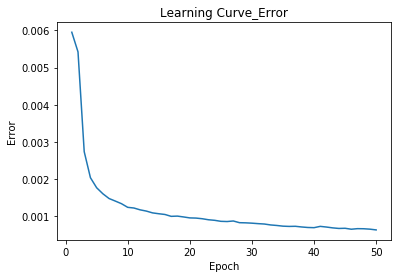

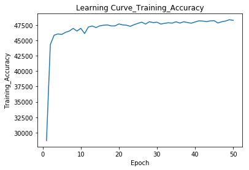

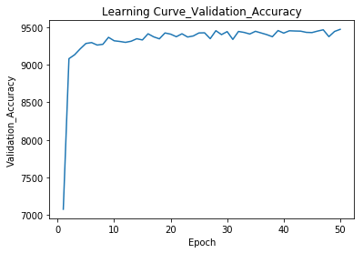

```python
#Your implementation goes here


from NeuralNet import *


my_mnist_net = NeuralNet(784,30,30,10,iterations=50, learning_rate = 1)


my_mnist_net.train_with_accuracy(training_data,validation_data)
```

```
Iteration:  1/50[==============] -Error: 0.0033237334  -Training_Accuracy:  53.40  -time: 17.94
Iteration:  2/50[==============] -Error: 0.0041552838  -Training_Accuracy:  77.83  -time: 42.48
Iteration:  3/50[==============] -Error: 0.0030195442  -Training_Accuracy:  80.06  -time: 71.37
Iteration:  4/50[==============] -Error: 0.0023676673  -Training_Accuracy:  88.99  -time: 100.43
Iteration:  5/50[==============] -Error: 0.0017970657  -Training_Accuracy:  89.70  -time: 121.92
Iteration:  6/50[==============] -Error: 0.0015383623  -Training_Accuracy:  86.26  -time: 148.44
Iteration:  7/50[==============] -Error: 0.0013702353  -Training_Accuracy:  90.96  -time: 172.14
Iteration:  8/50[==============] -Error: 0.0012865731  -Training_Accuracy:  91.59  -time: 199.19
Iteration:  9/50[==============] -Error: 0.0011854606  -Training_Accuracy:  91.84  -time: 227.52
Iteration: 10/50[==============] -Error: 0.0010778509  -Training_Accuracy:  91.10  -time: 250.37
Iteration: 11/50[==============] -Error: 0.0010103947  -Training_Accuracy:  91.95  -time: 274.22
Iteration: 12/50[==============] -Error: 0.0009717630  -Training_Accuracy:  92.01  -time: 298.13
Iteration: 13/50[==============] -Error: 0.0009372845  -Training_Accuracy:  92.20  -time: 320.72
Iteration: 14/50[==============] -Error: 0.0008816995  -Training_Accuracy:  92.33  -time: 343.63
Iteration: 15/50[==============] -Error: 0.0008873513  -Training_Accuracy:  93.17  -time: 367.05
Iteration: 16/50[==============] -Error: 0.0008561824  -Training_Accuracy:  93.11  -time: 391.73
Iteration: 17/50[==============] -Error: 0.0008212109  -Training_Accuracy:  91.09  -time: 423.19
Iteration: 18/50[==============] -Error: 0.0007851232  -Training_Accuracy:  92.76  -time: 447.30
Iteration: 19/50[==============] -Error: 0.0007745880  -Training_Accuracy:  91.82  -time: 470.69
Iteration: 20/50[==============] -Error: 0.0007595324  -Training_Accuracy:  93.30  -time: 493.71
Iteration: 21/50[==============] -Error: 0.0007720829  -Training_Accuracy:  93.75  -time: 516.52
Iteration: 22/50[==============] -Error: 0.0007093136  -Training_Accuracy:  92.53  -time: 539.19
Iteration: 23/50[==============] -Error: 0.0007244182  -Training_Accuracy:  93.02  -time: 565.72
Iteration: 24/50[==============] -Error: 0.0007118838  -Training_Accuracy:  92.72  -time: 588.50
Iteration: 25/50[==============] -Error: 0.0007024030  -Training_Accuracy:  93.65  -time: 612.26
Iteration: 26/50[==============] -Error: 0.0006680018  -Training_Accuracy:  94.04  -time: 638.01
Iteration: 27/50[==============] -Error: 0.0006479862  -Training_Accuracy:  93.56  -time: 660.96
Iteration: 28/50[==============] -Error: 0.0006360260  -Training_Accuracy:  93.24  -time: 683.21
Iteration: 29/50[==============] -Error: 0.0006468971  -Training_Accuracy:  93.14  -time: 706.45
Iteration: 30/50[==============] -Error: 0.0006456088  -Training_Accuracy:  93.60  -time: 730.69
Iteration: 31/50[==============] -Error: 0.0006413613  -Training_Accuracy:  94.06  -time: 757.08
Iteration: 32/50[==============] -Error: 0.0006057073  -Training_Accuracy:  93.37  -time: 782.83
Iteration: 33/50[==============] -Error: 0.0005998984  -Training_Accuracy:  93.85  -time: 806.03
Iteration: 34/50[==============] -Error: 0.0005972520  -Training_Accuracy:  94.19  -time: 828.73
Iteration: 35/50[==============] -Error: 0.0005942283  -Training_Accuracy:  93.89  -time: 850.34
Iteration: 36/50[==============] -Error: 0.0005827886  -Training_Accuracy:  93.92  -time: 871.66
Iteration: 37/50[==============] -Error: 0.0005926820  -Training_Accuracy:  94.13  -time: 893.01
Iteration: 38/50[==============] -Error: 0.0005883830  -Training_Accuracy:  94.24  -time: 914.29
Iteration: 39/50[==============] -Error: 0.0005564724  -Training_Accuracy:  94.07  -time: 935.75
Iteration: 40/50[==============] -Error: 0.0005433433  -Training_Accuracy:  94.49  -time: 957.13
Iteration: 41/50[==============] -Error: 0.0005257589  -Training_Accuracy:  93.72  -time: 978.34
Iteration: 42/50[==============] -Error: 0.0005441831  -Training_Accuracy:  93.61  -time: 999.63
Iteration: 43/50[==============] -Error: 0.0005189227  -Training_Accuracy:  94.01  -time: 1021.28
Iteration: 44/50[==============] -Error: 0.0005406467  -Training_Accuracy:  94.35  -time: 1042.54
Iteration: 45/50[==============] -Error: 0.0005140420  -Training_Accuracy:  94.76  -time: 1064.13
Iteration: 46/50[==============] -Error: 0.0005037415  -Training_Accuracy:  94.39  -time: 1086.45
Iteration: 47/50[==============] -Error: 0.0004978862  -Training_Accuracy:  94.59  -time: 1109.36
Iteration: 48/50[==============] -Error: 0.0004877286  -Training_Accuracy:  94.11  -time: 1131.20
Iteration: 49/50[==============] -Error: 0.0004822466  -Training_Accuracy:  94.34  -time: 1153.43
Iteration: 50/50[==============] -Error: 0.0005001012  -Training_Accuracy:  94.63  -time: 1176.96
```

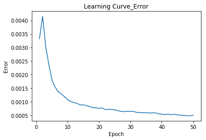

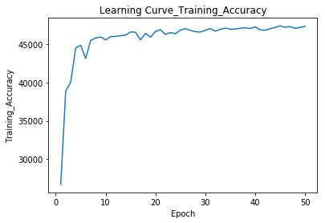

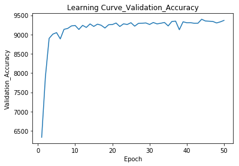

```python
from NeuralNet import *


my_mnist_net_layers= NeuralNet(784,30,100,10,iterations=50, learning_rate = 1)


my_mnist_net_layers.train_with_accuracy(training_data,validation_data)
```

```
Iteration:  1/50[==============] -Error: 0.0000013431  -Training_Accuracy:  11.36  -time: 24.61
Iteration:  2/50[==============] -Error: 0.0000003728  -Training_Accuracy:  10.35  -time: 44.64
Iteration:  3/50[==============] -Error: 0.0000002268  -Training_Accuracy:  9.94  -time: 64.01
Iteration:  4/50[==============] -Error: 0.0000000000  -Training_Accuracy:  9.94  -time: 83.97
Iteration:  5/50[==============] -Error: 0.0000002175  -Training_Accuracy:  9.68  -time: 104.08
Iteration:  6/50[==============] -Error: 0.0000001683  -Training_Accuracy:  9.86  -time: 123.46
Iteration:  7/50[==============] -Error: 0.0000000000  -Training_Accuracy:  9.86  -time: 143.84
Iteration:  8/50[==============] -Error: 0.0000000000  -Training_Accuracy:  9.86  -time: 163.95
Iteration:  9/50[==============] -Error: 0.0000001764  -Training_Accuracy:  9.72  -time: 186.71
Iteration: 10/50[==============] -Error: 0.0000000000  -Training_Accuracy:  9.72  -time: 212.72
Iteration: 11/50[==============] -Error: 0.0000000000  -Training_Accuracy:  9.72  -time: 234.02
Iteration: 12/50[==============] -Error: 0.0000000000  -Training_Accuracy:  9.72  -time: 254.70
Iteration: 13/50[==============] -Error: 0.0000000000  -Training_Accuracy:  9.72  -time: 276.50
Iteration: 14/50[==============] -Error: 0.0000000000  -Training_Accuracy:  9.72  -time: 297.15
Iteration: 15/50[==============] -Error: 0.0000000000  -Training_Accuracy:  9.72  -time: 317.54
Iteration: 16/50[==============] -Error: 0.0000000000  -Training_Accuracy:  9.72  -time: 338.95
Iteration: 17/50[==============] -Error: 0.0000000000  -Training_Accuracy:  9.72  -time: 360.88
Iteration: 18/50[==============] -Error: 0.0000000000  -Training_Accuracy:  9.72  -time: 381.50
Iteration: 19/50[==============] -Error: 0.0000000000  -Training_Accuracy:  9.72  -time: 404.21
Iteration: 20/50[==============] -Error: 0.0000000000  -Training_Accuracy:  9.72  -time: 426.85
Iteration: 21/50[==============] -Error: 0.0000000000  -Training_Accuracy:  9.72  -time: 448.48
Iteration: 22/50[==============] -Error: 0.0000000000  -Training_Accuracy:  9.72  -time: 477.38
Iteration: 23/50[==============] -Error: 0.0000000000  -Training_Accuracy:  9.72  -time: 499.14
Iteration: 24/50[==============] -Error: 0.0000000000  -Training_Accuracy:  9.72  -time: 523.74
Iteration: 25/50[==============] -Error: 0.0000000000  -Training_Accuracy:  9.72  -time: 545.56
Iteration: 26/50[==============] -Error: 0.0000000000  -Training_Accuracy:  9.72  -time: 570.15
Iteration: 27/50[==============] -Error: 0.0000000000  -Training_Accuracy:  9.72  -time: 596.96
Iteration: 28/50[==============] -Error: 0.0000000000  -Training_Accuracy:  9.72  -time: 618.64
Iteration: 29/50[==============] -Error: 0.0000000000  -Training_Accuracy:  9.72  -time: 641.49
Iteration: 30/50[==============] -Error: 0.0000000000  -Training_Accuracy:  9.72  -time: 663.49
Iteration: 31/50[==============] -Error: 0.0000002461  -Training_Accuracy:  9.68  -time: 685.17
Iteration: 32/50[==============] -Error: 0.0000000000  -Training_Accuracy:  9.68  -time: 706.75
Iteration: 33/50[==============] -Error: 0.0000000000  -Training_Accuracy:  9.68  -time: 727.45
Iteration: 34/50[==============] -Error: 0.0000000000  -Training_Accuracy:  9.68  -time: 748.37
Iteration: 35/50[==============] -Error: 0.0000000000  -Training_Accuracy:  9.68  -time: 769.86
Iteration: 36/50[==============] -Error: 0.0000000000  -Training_Accuracy:  9.68  -time: 793.19
Iteration: 37/50[==============] -Error: 0.0000000000  -Training_Accuracy:  9.68  -time: 819.41
Iteration: 38/50[==============] -Error: 0.0000000000  -Training_Accuracy:  9.68  -time: 846.10
Iteration: 39/50[==============] -Error: 0.0000000000  -Training_Accuracy:  9.68  -time: 870.84
Iteration: 40/50[==============] -Error: 0.0000000000  -Training_Accuracy:  9.68  -time: 894.05
Iteration: 41/50[==============] -Error: 0.0000000000  -Training_Accuracy:  9.68  -time: 920.36
Iteration: 42/50[==============] -Error: 0.0000000000  -Training_Accuracy:  9.68  -time: 942.92
Iteration: 43/50[==============] -Error: 0.0000000000  -Training_Accuracy:  9.68  -time: 963.79
Iteration: 44/50[==============] -Error: 0.0000000000  -Training_Accuracy:  9.68  -time: 985.72
Iteration: 45/50[==============] -Error: 0.0000000000  -Training_Accuracy:  9.68  -time: 1014.36
Iteration: 46/50[==============] -Error: 0.0000000000  -Training_Accuracy:  9.68  -time: 1036.37
Iteration: 47/50[==============] -Error: 0.0000000000  -Training_Accuracy:  9.68  -time: 1058.50
Iteration: 48/50[==============] -Error: 0.0000000000  -Training_Accuracy:  9.68  -time: 1079.23
Iteration: 49/50[==============] -Error: 0.0000000000  -Training_Accuracy:  9.68  -time: 1100.65
Iteration: 50/50[==============] -Error: 0.0000000000  -Training_Accuracy:  9.68  -time: 1127.43
```

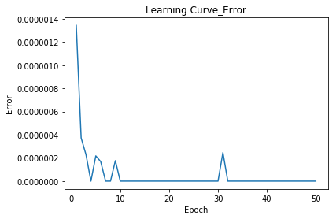

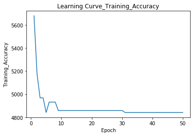

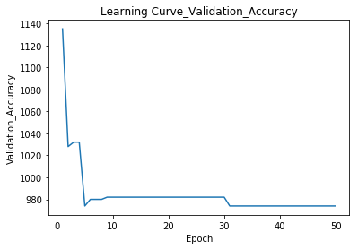

```python
#Your implementation goes here


from NeuralNet import *


my_mnist_net = NeuralNet(784,30,30,10,iterations=50, learning_rate = 10)


my_mnist_net.train_with_accuracy(training_data,validation_data)
```

Howeover, when we increase the learning rate, we can observe that the training accuracy is very low ( less than 10 % ), so the model is worst.